# Expansión de la CASEN sobre el CENSO (Región 01)

### 1.2 Cálculo de frecuencias

```r
tabla_con_clave_f <- tabla_con_clave[,-c(1,2,4,5,6,7,8,9,10,11,12,14,15,16,17,18,19,20),drop=FALSE]
```

```r
names(tabla_con_clave_f)[2] <- "Tipo de piso"
```

```r
# Ahora filtramos por Tipo de techo = 1.
tabla_con_clave_ff <- filter(tabla_con_clave_f, tabla_con_clave_f$`Tipo de piso` == 1)
```

```r
# Determinamos las frecuencias por zona:
b <- tabla_con_clave_ff$clave
c <- tabla_con_clave_ff$`Tipo de piso`
d <- tabla_con_clave_ff$COMUNA
cross_tab =  xtabs( ~ unlist(b) + unlist(c)+ unlist(d))
tabla <- as.data.frame(cross_tab)
d <-tabla[!(tabla$Freq == 0),]
names(d)[1] <- "zona"
d$anio <- "2017"
```

Veamos los primeros 100 registros:

```r
r3_100 <- d[c(1:100),]
kbl(r3_100) %>%
  kable_styling(bootstrap_options = c("striped", "hover")) %>%
  kable_paper() %>%
  scroll_box(width = "100%", height = "300px")
```

|  | zona | unlist.c. | unlist.d. | Freq | anio |
| --- | --- | --- | --- | --- | --- |
| 233 | 1101011001 | 1 | 1101 | 807 | 2017 |
| 234 | 1101011002 | 1 | 1101 | 452 | 2017 |
| 235 | 1101021001 | 1 | 1101 | 257 | 2017 |
| 236 | 1101021002 | 1 | 1101 | 11 | 2017 |
| 237 | 1101021003 | 1 | 1101 | 571 | 2017 |
| 238 | 1101021004 | 1 | 1101 | 451 | 2017 |
| 239 | 1101021005 | 1 | 1101 | 1046 | 2017 |
| 240 | 1101031001 | 1 | 1101 | 653 | 2017 |
| 241 | 1101031002 | 1 | 1101 | 837 | 2017 |
| 242 | 1101031003 | 1 | 1101 | 1315 | 2017 |
| 243 | 1101031004 | 1 | 1101 | 903 | 2017 |
| 244 | 1101041001 | 1 | 1101 | 417 | 2017 |
| 245 | 1101041002 | 1 | 1101 | 524 | 2017 |
| 246 | 1101041003 | 1 | 1101 | 1036 | 2017 |
| 247 | 1101041004 | 1 | 1101 | 1406 | 2017 |
| 248 | 1101041005 | 1 | 1101 | 894 | 2017 |
| 249 | 1101041006 | 1 | 1101 | 588 | 2017 |
| 250 | 1101051001 | 1 | 1101 | 857 | 2017 |
| 251 | 1101051002 | 1 | 1101 | 1279 | 2017 |
| 252 | 1101051003 | 1 | 1101 | 1252 | 2017 |
| 253 | 1101051004 | 1 | 1101 | 558 | 2017 |
| 254 | 1101051005 | 1 | 1101 | 1207 | 2017 |
| 255 | 1101051006 | 1 | 1101 | 858 | 2017 |
| 256 | 1101061001 | 1 | 1101 | 606 | 2017 |
| 257 | 1101061002 | 1 | 1101 | 1338 | 2017 |
| 258 | 1101061003 | 1 | 1101 | 1436 | 2017 |
| 259 | 1101061004 | 1 | 1101 | 1294 | 2017 |
| 260 | 1101061005 | 1 | 1101 | 626 | 2017 |
| 261 | 1101071001 | 1 | 1101 | 691 | 2017 |
| 262 | 1101071002 | 1 | 1101 | 753 | 2017 |

[output cut: 70 more lines]

Agregamos un cero a los códigos comunales de cuatro dígitos:

```r
codigos <- d$unlist.d.
rango <- seq(1:nrow(d))
cadena <- paste("0",codigos[rango], sep = "")
cadena <- substr(cadena,(nchar(cadena)[rango])-(4),6)
codigos <- as.data.frame(codigos)
cadena <- as.data.frame(cadena)
comuna_corr <- cbind(d,cadena)
comuna_corr <- comuna_corr[,-c(2,3),drop=FALSE]
names(comuna_corr)[4] <- "código"
r3_100 <- comuna_corr[c(1:100),]
kbl(r3_100) %>%
  kable_styling(bootstrap_options = c("striped", "hover")) %>%
  kable_paper() %>%
  scroll_box(width = "100%", height = "300px")
```

|  | zona | Freq | anio | código |
| --- | --- | --- | --- | --- |
| 233 | 1101011001 | 807 | 2017 | 01101 |
| 234 | 1101011002 | 452 | 2017 | 01101 |
| 235 | 1101021001 | 257 | 2017 | 01101 |
| 236 | 1101021002 | 11 | 2017 | 01101 |
| 237 | 1101021003 | 571 | 2017 | 01101 |
| 238 | 1101021004 | 451 | 2017 | 01101 |
| 239 | 1101021005 | 1046 | 2017 | 01101 |
| 240 | 1101031001 | 653 | 2017 | 01101 |
| 241 | 1101031002 | 837 | 2017 | 01101 |
| 242 | 1101031003 | 1315 | 2017 | 01101 |
| 243 | 1101031004 | 903 | 2017 | 01101 |
| 244 | 1101041001 | 417 | 2017 | 01101 |
| 245 | 1101041002 | 524 | 2017 | 01101 |
| 246 | 1101041003 | 1036 | 2017 | 01101 |
| 247 | 1101041004 | 1406 | 2017 | 01101 |
| 248 | 1101041005 | 894 | 2017 | 01101 |
| 249 | 1101041006 | 588 | 2017 | 01101 |
| 250 | 1101051001 | 857 | 2017 | 01101 |
| 251 | 1101051002 | 1279 | 2017 | 01101 |
| 252 | 1101051003 | 1252 | 2017 | 01101 |
| 253 | 1101051004 | 558 | 2017 | 01101 |
| 254 | 1101051005 | 1207 | 2017 | 01101 |
| 255 | 1101051006 | 858 | 2017 | 01101 |
| 256 | 1101061001 | 606 | 2017 | 01101 |
| 257 | 1101061002 | 1338 | 2017 | 01101 |
| 258 | 1101061003 | 1436 | 2017 | 01101 |
| 259 | 1101061004 | 1294 | 2017 | 01101 |
| 260 | 1101061005 | 626 | 2017 | 01101 |
| 261 | 1101071001 | 691 | 2017 | 01101 |
| 262 | 1101071002 | 753 | 2017 | 01101 |

[output cut: 70 more lines]

## 2 Variable CASEN

### 2.1 Tabla de ingresos expandidos

Hemos calculado ya éste valor como conclusión del punto 1.1 de [aquí](https://rpubs.com/dataintelligence/corr_casen_censo_002)

```r
h_y_m_2017_censo <- readRDS("../corre_ing_exp-censo_casen/ingresos_expandidos_urbano_17.rds")
tablamadre <- head(h_y_m_2017_censo,50)
kbl(tablamadre) %>%
  kable_styling(bootstrap_options = c("striped", "hover")) %>%
  kable_paper() %>%
  scroll_box(width = "100%", height = "300px")
```

| código | comuna.x | promedio_i | año | personas | Ingresos_expandidos |
| --- | --- | --- | --- | --- | --- |
| 01101 | Iquique | 375676.9 | 2017 | 191468 | 71930106513 |
| 01107 | Alto Hospicio | 311571.7 | 2017 | 108375 | 33766585496 |
| 01401 | Pozo Almonte | 316138.5 | 2017 | 15711 | 4966851883 |
| 01405 | Pica | 330061.1 | 2017 | 9296 | 3068247619 |
| 02101 | Antofagasta | 368221.4 | 2017 | 361873 | 133249367039 |
| 02102 | Mejillones | 369770.7 | 2017 | 13467 | 4979702302 |
| 02104 | Taltal | 383666.2 | 2017 | 13317 | 5109282942 |
| 02201 | Calama | 434325.1 | 2017 | 165731 | 71981127235 |
| 02203 | San Pedro de Atacama | 442861.0 | 2017 | 10996 | 4869699464 |
| 02301 | Tocopilla | 286187.2 | 2017 | 25186 | 7207910819 |
| 02302 | María Elena | 477748.0 | 2017 | 6457 | 3084818966 |
| 03101 | Copiapó | 343121.0 | 2017 | 153937 | 52819016037 |
| 03102 | Caldera | 318653.2 | 2017 | 17662 | 5628052276 |
| 03103 | Tierra Amarilla | 333194.9 | 2017 | 14019 | 4671058718 |
| 03201 | Chañaral | 286389.3 | 2017 | 12219 | 3499391196 |
| 03202 | Diego de Almagro | 351583.9 | 2017 | 13925 | 4895805596 |
| 03301 | Vallenar | 315981.5 | 2017 | 51917 | 16404810756 |
| 03303 | Freirina | 289049.9 | 2017 | 7041 | 2035200054 |
| 03304 | Huasco | 337414.8 | 2017 | 10149 | 3424422750 |
| 04101 | La Serena | 279340.1 | 2017 | 221054 | 61749247282 |
| 04102 | Coquimbo | 269078.6 | 2017 | 227730 | 61277269093 |
| 04103 | Andacollo | 258539.7 | 2017 | 11044 | 2855312920 |
| 04104 | La Higuera | 214257.0 | 2017 | 4241 | 908664019 |
| 04106 | Vicuña | 254177.0 | 2017 | 27771 | 7058750373 |
| 04201 | Illapel | 282139.3 | 2017 | 30848 | 8703433491 |
| 04202 | Canela | 233397.3 | 2017 | 9093 | 2122281844 |
| 04203 | Los Vilos | 285214.0 | 2017 | 21382 | 6098444926 |
| 04204 | Salamanca | 262056.9 | 2017 | 29347 | 7690585032 |
| 04301 | Ovalle | 280373.5 | 2017 | 111272 | 31197719080 |
| 04302 | Combarbalá | 234537.3 | 2017 | 13322 | 3124505460 |
| 04303 | Monte Patria | 225369.1 | 2017 | 30751 | 6930326684 |
| 04304 | Punitaqui | 212496.1 | 2017 | 10956 | 2328107498 |
| 05101 | Valparaíso | 306572.5 | 2017 | 296655 | 90946261553 |
| 05102 | Casablanca | 348088.6 | 2017 | 26867 | 9352095757 |
| 05103 | Concón | 333932.4 | 2017 | 42152 | 14075920021 |
| 05105 | Puchuncaví | 296035.5 | 2017 | 18546 | 5490274928 |
| 05107 | Quintero | 308224.7 | 2017 | 31923 | 9839456903 |
| 05109 | Viña del Mar | 354715.9 | 2017 | 334248 | 118563074323 |
| 05301 | Los Andes | 355446.2 | 2017 | 66708 | 23711104774 |
| 05302 | Calle Larga | 246387.3 | 2017 | 14832 | 3654416747 |
| 05303 | Rinconada | 279807.9 | 2017 | 10207 | 2855998928 |
| 05304 | San Esteban | 219571.6 | 2017 | 18855 | 4140022481 |
| 05401 | La Ligua | 259482.3 | 2017 | 35390 | 9183080280 |
| 05402 | Cabildo | 262745.9 | 2017 | 19388 | 5094117762 |
| 05403 | Papudo | 302317.1 | 2017 | 6356 | 1921527704 |
| 05404 | Petorca | 237510.8 | 2017 | 9826 | 2333781007 |
| 05405 | Zapallar | 294389.2 | 2017 | 7339 | 2160521991 |
| 05501 | Quillota | 288694.2 | 2017 | 90517 | 26131733924 |
| 05502 | Calera | 282823.6 | 2017 | 50554 | 14297866792 |
| 05503 | Hijuelas | 268449.7 | 2017 | 17988 | 4828872604 |

## 3 Unión Censo-Casen

Integramos a la tabla censal de frecuencias la tabla de ingresos expandidos de la Casen.

```r
comunas_con_ing_exp = merge( x = comuna_corr, y = h_y_m_2017_censo, by = "código", all.x = TRUE)
comunas_con_ing_exp <-comunas_con_ing_exp[!(is.na(comunas_con_ing_exp$Ingresos_expandidos)),]
r3_100 <- comunas_con_ing_exp[c(1:100),]
kbl(r3_100) %>%
  kable_styling(bootstrap_options = c("striped", "hover")) %>%
  kable_paper() %>%
  scroll_box(width = "100%", height = "300px")
```

|  | código | zona | Freq | anio | comuna.x | promedio_i | año | personas | Ingresos_expandidos |
| --- | --- | --- | --- | --- | --- | --- | --- | --- | --- |
| 1 | 01101 | 1101011002 | 452 | 2017 | Iquique | 375676.9 | 2017 | 191468 | 71930106513 |
| 2 | 01101 | 1101021003 | 571 | 2017 | Iquique | 375676.9 | 2017 | 191468 | 71930106513 |
| 3 | 01101 | 1101021004 | 451 | 2017 | Iquique | 375676.9 | 2017 | 191468 | 71930106513 |
| 4 | 01101 | 1101051002 | 1279 | 2017 | Iquique | 375676.9 | 2017 | 191468 | 71930106513 |
| 5 | 01101 | 1101021005 | 1046 | 2017 | Iquique | 375676.9 | 2017 | 191468 | 71930106513 |
| 6 | 01101 | 1101041001 | 417 | 2017 | Iquique | 375676.9 | 2017 | 191468 | 71930106513 |
| 7 | 01101 | 1101011001 | 807 | 2017 | Iquique | 375676.9 | 2017 | 191468 | 71930106513 |
| 8 | 01101 | 1101041003 | 1036 | 2017 | Iquique | 375676.9 | 2017 | 191468 | 71930106513 |
| 9 | 01101 | 1101041004 | 1406 | 2017 | Iquique | 375676.9 | 2017 | 191468 | 71930106513 |
| 10 | 01101 | 1101041005 | 894 | 2017 | Iquique | 375676.9 | 2017 | 191468 | 71930106513 |
| 11 | 01101 | 1101051001 | 857 | 2017 | Iquique | 375676.9 | 2017 | 191468 | 71930106513 |
| 12 | 01101 | 1101071003 | 1050 | 2017 | Iquique | 375676.9 | 2017 | 191468 | 71930106513 |
| 13 | 01101 | 1101071004 | 605 | 2017 | Iquique | 375676.9 | 2017 | 191468 | 71930106513 |
| 14 | 01101 | 1101051003 | 1252 | 2017 | Iquique | 375676.9 | 2017 | 191468 | 71930106513 |
| 15 | 01101 | 1101041006 | 588 | 2017 | Iquique | 375676.9 | 2017 | 191468 | 71930106513 |
| 16 | 01101 | 1101081003 | 658 | 2017 | Iquique | 375676.9 | 2017 | 191468 | 71930106513 |
| 17 | 01101 | 1101081004 | 762 | 2017 | Iquique | 375676.9 | 2017 | 191468 | 71930106513 |
| 18 | 01101 | 1101031004 | 903 | 2017 | Iquique | 375676.9 | 2017 | 191468 | 71930106513 |
| 19 | 01101 | 1101101002 | 993 | 2017 | Iquique | 375676.9 | 2017 | 191468 | 71930106513 |
| 20 | 01101 | 1101041002 | 524 | 2017 | Iquique | 375676.9 | 2017 | 191468 | 71930106513 |
| 21 | 01101 | 1101101004 | 838 | 2017 | Iquique | 375676.9 | 2017 | 191468 | 71930106513 |
| 22 | 01101 | 1101101005 | 1215 | 2017 | Iquique | 375676.9 | 2017 | 191468 | 71930106513 |
| 23 | 01101 | 1101101006 | 940 | 2017 | Iquique | 375676.9 | 2017 | 191468 | 71930106513 |
| 24 | 01101 | 1101021001 | 257 | 2017 | Iquique | 375676.9 | 2017 | 191468 | 71930106513 |
| 25 | 01101 | 1101021002 | 11 | 2017 | Iquique | 375676.9 | 2017 | 191468 | 71930106513 |
| 26 | 01101 | 1101111003 | 1242 | 2017 | Iquique | 375676.9 | 2017 | 191468 | 71930106513 |
| 27 | 01101 | 1101111004 | 1078 | 2017 | Iquique | 375676.9 | 2017 | 191468 | 71930106513 |
| 28 | 01101 | 1101111005 | 1235 | 2017 | Iquique | 375676.9 | 2017 | 191468 | 71930106513 |
| 29 | 01101 | 1101111006 | 1039 | 2017 | Iquique | 375676.9 | 2017 | 191468 | 71930106513 |
| 30 | 01101 | 1101111007 | 827 | 2017 | Iquique | 375676.9 | 2017 | 191468 | 71930106513 |

[output cut: 70 more lines]

## 4 Proporción poblacional zonal respecto a la comunal

Del censo obtenemos la cantidad de población a nivel de zona y estimamos su proporción a nivel comunal. Ya hemos calculado ésta proporción [aquí](https://rpubs.com/dataintelligence/tabla_de_proporciones).

```r
prop_pob <- readRDS("../tabla_de_prop_pob.rds")
names(prop_pob)[1] <- "zona"
names(prop_pob)[3] <- "p_poblacional"
```

Veamos los 100 primeros registros:

```r
r3_100 <- prop_pob[c(1:100),]
kbl(r3_100) %>%
  kable_styling(bootstrap_options = c("striped", "hover")) %>%
  kable_paper() %>%
  scroll_box(width = "100%", height = "300px")
```

| zona | Freq | p_poblacional | código |
| --- | --- | --- | --- |
| 1101011001 | 2491 | 0.0130100 | 01101 |
| 1101011002 | 1475 | 0.0077036 | 01101 |
| 1101021001 | 1003 | 0.0052385 | 01101 |
| 1101021002 | 54 | 0.0002820 | 01101 |
| 1101021003 | 2895 | 0.0151200 | 01101 |
| 1101021004 | 2398 | 0.0125243 | 01101 |
| 1101021005 | 4525 | 0.0236332 | 01101 |
| 1101031001 | 2725 | 0.0142321 | 01101 |
| 1101031002 | 3554 | 0.0185618 | 01101 |
| 1101031003 | 5246 | 0.0273988 | 01101 |
| 1101031004 | 3389 | 0.0177001 | 01101 |
| 1101041001 | 1800 | 0.0094010 | 01101 |
| 1101041002 | 2538 | 0.0132555 | 01101 |
| 1101041003 | 3855 | 0.0201339 | 01101 |
| 1101041004 | 5663 | 0.0295767 | 01101 |
| 1101041005 | 4162 | 0.0217373 | 01101 |
| 1101041006 | 2689 | 0.0140441 | 01101 |
| 1101051001 | 3296 | 0.0172144 | 01101 |
| 1101051002 | 4465 | 0.0233198 | 01101 |
| 1101051003 | 4656 | 0.0243174 | 01101 |
| 1101051004 | 2097 | 0.0109522 | 01101 |
| 1101051005 | 3569 | 0.0186402 | 01101 |
| 1101051006 | 2741 | 0.0143157 | 01101 |
| 1101061001 | 1625 | 0.0084871 | 01101 |
| 1101061002 | 4767 | 0.0248971 | 01101 |
| 1101061003 | 4826 | 0.0252053 | 01101 |
| 1101061004 | 4077 | 0.0212934 | 01101 |
| 1101061005 | 2166 | 0.0113126 | 01101 |
| 1101071001 | 2324 | 0.0121378 | 01101 |
| 1101071002 | 2801 | 0.0146291 | 01101 |

[output cut: 70 more lines]

## 5 Ingreso medio

Deseamos el valor del ingreso promedio a nivel comunal, pero expandido a nivel zonal. Ésta información está contenida en el campo promedio_i de la tabla obtenida en el punto 3.

```r
r3_100 <- comunas_con_ing_exp[c(1:100),]
kbl(r3_100) %>%
  kable_styling(bootstrap_options = c("striped", "hover")) %>%
  kable_paper() %>%
  scroll_box(width = "100%", height = "300px")
```

|  | código | zona | Freq | anio | comuna.x | promedio_i | año | personas | Ingresos_expandidos |
| --- | --- | --- | --- | --- | --- | --- | --- | --- | --- |
| 1 | 01101 | 1101011002 | 452 | 2017 | Iquique | 375676.9 | 2017 | 191468 | 71930106513 |
| 2 | 01101 | 1101021003 | 571 | 2017 | Iquique | 375676.9 | 2017 | 191468 | 71930106513 |
| 3 | 01101 | 1101021004 | 451 | 2017 | Iquique | 375676.9 | 2017 | 191468 | 71930106513 |
| 4 | 01101 | 1101051002 | 1279 | 2017 | Iquique | 375676.9 | 2017 | 191468 | 71930106513 |
| 5 | 01101 | 1101021005 | 1046 | 2017 | Iquique | 375676.9 | 2017 | 191468 | 71930106513 |
| 6 | 01101 | 1101041001 | 417 | 2017 | Iquique | 375676.9 | 2017 | 191468 | 71930106513 |
| 7 | 01101 | 1101011001 | 807 | 2017 | Iquique | 375676.9 | 2017 | 191468 | 71930106513 |
| 8 | 01101 | 1101041003 | 1036 | 2017 | Iquique | 375676.9 | 2017 | 191468 | 71930106513 |
| 9 | 01101 | 1101041004 | 1406 | 2017 | Iquique | 375676.9 | 2017 | 191468 | 71930106513 |
| 10 | 01101 | 1101041005 | 894 | 2017 | Iquique | 375676.9 | 2017 | 191468 | 71930106513 |
| 11 | 01101 | 1101051001 | 857 | 2017 | Iquique | 375676.9 | 2017 | 191468 | 71930106513 |
| 12 | 01101 | 1101071003 | 1050 | 2017 | Iquique | 375676.9 | 2017 | 191468 | 71930106513 |
| 13 | 01101 | 1101071004 | 605 | 2017 | Iquique | 375676.9 | 2017 | 191468 | 71930106513 |
| 14 | 01101 | 1101051003 | 1252 | 2017 | Iquique | 375676.9 | 2017 | 191468 | 71930106513 |
| 15 | 01101 | 1101041006 | 588 | 2017 | Iquique | 375676.9 | 2017 | 191468 | 71930106513 |
| 16 | 01101 | 1101081003 | 658 | 2017 | Iquique | 375676.9 | 2017 | 191468 | 71930106513 |
| 17 | 01101 | 1101081004 | 762 | 2017 | Iquique | 375676.9 | 2017 | 191468 | 71930106513 |
| 18 | 01101 | 1101031004 | 903 | 2017 | Iquique | 375676.9 | 2017 | 191468 | 71930106513 |
| 19 | 01101 | 1101101002 | 993 | 2017 | Iquique | 375676.9 | 2017 | 191468 | 71930106513 |
| 20 | 01101 | 1101041002 | 524 | 2017 | Iquique | 375676.9 | 2017 | 191468 | 71930106513 |
| 21 | 01101 | 1101101004 | 838 | 2017 | Iquique | 375676.9 | 2017 | 191468 | 71930106513 |
| 22 | 01101 | 1101101005 | 1215 | 2017 | Iquique | 375676.9 | 2017 | 191468 | 71930106513 |
| 23 | 01101 | 1101101006 | 940 | 2017 | Iquique | 375676.9 | 2017 | 191468 | 71930106513 |
| 24 | 01101 | 1101021001 | 257 | 2017 | Iquique | 375676.9 | 2017 | 191468 | 71930106513 |
| 25 | 01101 | 1101021002 | 11 | 2017 | Iquique | 375676.9 | 2017 | 191468 | 71930106513 |
| 26 | 01101 | 1101111003 | 1242 | 2017 | Iquique | 375676.9 | 2017 | 191468 | 71930106513 |
| 27 | 01101 | 1101111004 | 1078 | 2017 | Iquique | 375676.9 | 2017 | 191468 | 71930106513 |
| 28 | 01101 | 1101111005 | 1235 | 2017 | Iquique | 375676.9 | 2017 | 191468 | 71930106513 |
| 29 | 01101 | 1101111006 | 1039 | 2017 | Iquique | 375676.9 | 2017 | 191468 | 71930106513 |
| 30 | 01101 | 1101111007 | 827 | 2017 | Iquique | 375676.9 | 2017 | 191468 | 71930106513 |

[output cut: 70 more lines]

## 6 Ingreso promedio expandido por zona (**multi_pob**)

En éste momento vamos a construir nuestra variable dependiente de regresión aplicando la siguiente fórmula:

$$multi\_pob = promedio\_i \cdot personas \cdot p\_poblacional$$

Para ello integramos a la tabla de ingresos expandidos a nivel zonal (punto 3) la tabla de proporciones poblacionales zonales respecto al total comunal (punto 4) :

```r
h_y_m_comuna_corr_01 = merge( x = comunas_con_ing_exp, y = prop_pob, by = "zona", all.x = TRUE)
tablamadre <- head(h_y_m_comuna_corr_01,100)
kbl(tablamadre) %>%
  kable_styling(bootstrap_options = c("striped", "hover")) %>%
  kable_paper() %>%
  scroll_box(width = "100%", height = "300px")
```

| zona | código.x | Freq.x | anio | comuna.x | promedio_i | año | personas | Ingresos_expandidos | Freq.y | p_poblacional | código.y |
| --- | --- | --- | --- | --- | --- | --- | --- | --- | --- | --- | --- |
| 10101011001 | 10101 | 181 | 2017 | Puerto Montt | 304409.6 | 2017 | 245902 | 74854925754 | 584 | 0.0023749 | 10101 |
| 10101011002 | 10101 | 964 | 2017 | Puerto Montt | 304409.6 | 2017 | 245902 | 74854925754 | 2941 | 0.0119600 | 10101 |
| 10101021001 | 10101 | 1249 | 2017 | Puerto Montt | 304409.6 | 2017 | 245902 | 74854925754 | 3953 | 0.0160755 | 10101 |
| 10101021002 | 10101 | 328 | 2017 | Puerto Montt | 304409.6 | 2017 | 245902 | 74854925754 | 1107 | 0.0045018 | 10101 |
| 10101021003 | 10101 | 699 | 2017 | Puerto Montt | 304409.6 | 2017 | 245902 | 74854925754 | 2294 | 0.0093289 | 10101 |
| 10101021004 | 10101 | 1043 | 2017 | Puerto Montt | 304409.6 | 2017 | 245902 | 74854925754 | 3391 | 0.0137900 | 10101 |
| 10101021005 | 10101 | 773 | 2017 | Puerto Montt | 304409.6 | 2017 | 245902 | 74854925754 | 2564 | 0.0104269 | 10101 |
| 10101031001 | 10101 | 1468 | 2017 | Puerto Montt | 304409.6 | 2017 | 245902 | 74854925754 | 4530 | 0.0184220 | 10101 |
| 10101031002 | 10101 | 1424 | 2017 | Puerto Montt | 304409.6 | 2017 | 245902 | 74854925754 | 4740 | 0.0192760 | 10101 |
| 10101031003 | 10101 | 1163 | 2017 | Puerto Montt | 304409.6 | 2017 | 245902 | 74854925754 | 4107 | 0.0167018 | 10101 |
| 10101031004 | 10101 | 836 | 2017 | Puerto Montt | 304409.6 | 2017 | 245902 | 74854925754 | 2856 | 0.0116144 | 10101 |
| 10101031005 | 10101 | 1701 | 2017 | Puerto Montt | 304409.6 | 2017 | 245902 | 74854925754 | 5690 | 0.0231393 | 10101 |
| 10101031006 | 10101 | 704 | 2017 | Puerto Montt | 304409.6 | 2017 | 245902 | 74854925754 | 2460 | 0.0100040 | 10101 |
| 10101031007 | 10101 | 652 | 2017 | Puerto Montt | 304409.6 | 2017 | 245902 | 74854925754 | 2292 | 0.0093208 | 10101 |
| 10101031008 | 10101 | 1013 | 2017 | Puerto Montt | 304409.6 | 2017 | 245902 | 74854925754 | 3585 | 0.0145790 | 10101 |
| 10101031009 | 10101 | 1347 | 2017 | Puerto Montt | 304409.6 | 2017 | 245902 | 74854925754 | 4436 | 0.0180397 | 10101 |
| 10101031010 | 10101 | 910 | 2017 | Puerto Montt | 304409.6 | 2017 | 245902 | 74854925754 | 3566 | 0.0145017 | 10101 |
| 10101031011 | 10101 | 666 | 2017 | Puerto Montt | 304409.6 | 2017 | 245902 | 74854925754 | 2757 | 0.0112118 | 10101 |
| 10101031012 | 10101 | 499 | 2017 | Puerto Montt | 304409.6 | 2017 | 245902 | 74854925754 | 1849 | 0.0075193 | 10101 |
| 10101031013 | 10101 | 1055 | 2017 | Puerto Montt | 304409.6 | 2017 | 245902 | 74854925754 | 3945 | 0.0160430 | 10101 |
| 10101031014 | 10101 | 645 | 2017 | Puerto Montt | 304409.6 | 2017 | 245902 | 74854925754 | 2265 | 0.0092110 | 10101 |
| 10101031015 | 10101 | 541 | 2017 | Puerto Montt | 304409.6 | 2017 | 245902 | 74854925754 | 1930 | 0.0078487 | 10101 |
| 10101031016 | 10101 | 773 | 2017 | Puerto Montt | 304409.6 | 2017 | 245902 | 74854925754 | 3071 | 0.0124887 | 10101 |
| 10101031017 | 10101 | 821 | 2017 | Puerto Montt | 304409.6 | 2017 | 245902 | 74854925754 | 3885 | 0.0157990 | 10101 |
| 10101041001 | 10101 | 1331 | 2017 | Puerto Montt | 304409.6 | 2017 | 245902 | 74854925754 | 4342 | 0.0176574 | 10101 |
| 10101041002 | 10101 | 644 | 2017 | Puerto Montt | 304409.6 | 2017 | 245902 | 74854925754 | 2169 | 0.0088206 | 10101 |
| 10101041003 | 10101 | 1650 | 2017 | Puerto Montt | 304409.6 | 2017 | 245902 | 74854925754 | 5202 | 0.0211548 | 10101 |
| 10101051001 | 10101 | 825 | 2017 | Puerto Montt | 304409.6 | 2017 | 245902 | 74854925754 | 2463 | 0.0100162 | 10101 |
| 10101051002 | 10101 | 579 | 2017 | Puerto Montt | 304409.6 | 2017 | 245902 | 74854925754 | 1913 | 0.0077795 | 10101 |
| 10101051003 | 10101 | 888 | 2017 | Puerto Montt | 304409.6 | 2017 | 245902 | 74854925754 | 3272 | 0.0133061 | 10101 |

[output cut: 70 more lines]

Hacemos la multiplicación que queda almacenada en la variable **multi_pob**:

```r
h_y_m_comuna_corr_01$multi_pob <- h_y_m_comuna_corr_01$promedio_i * h_y_m_comuna_corr_01$personas * h_y_m_comuna_corr_01$p_poblacional
tablamadre <- head(h_y_m_comuna_corr_01,100)
kbl(tablamadre) %>%
  kable_styling(bootstrap_options = c("striped", "hover")) %>%
  kable_paper() %>%
  scroll_box(width = "100%", height = "300px")
```

| zona | código.x | Freq.x | anio | comuna.x | promedio_i | año | personas | Ingresos_expandidos | Freq.y | p_poblacional | código.y | multi_pob |
| --- | --- | --- | --- | --- | --- | --- | --- | --- | --- | --- | --- | --- |
| 10101011001 | 10101 | 181 | 2017 | Puerto Montt | 304409.6 | 2017 | 245902 | 74854925754 | 584 | 0.0023749 | 10101 | 177775197.6 |
| 10101011002 | 10101 | 964 | 2017 | Puerto Montt | 304409.6 | 2017 | 245902 | 74854925754 | 2941 | 0.0119600 | 10101 | 895268589.3 |
| 10101021001 | 10101 | 1249 | 2017 | Puerto Montt | 304409.6 | 2017 | 245902 | 74854925754 | 3953 | 0.0160755 | 10101 | 1203331089.2 |
| 10101021002 | 10101 | 328 | 2017 | Puerto Montt | 304409.6 | 2017 | 245902 | 74854925754 | 1107 | 0.0045018 | 10101 | 336981410.5 |
| 10101021003 | 10101 | 699 | 2017 | Puerto Montt | 304409.6 | 2017 | 245902 | 74854925754 | 2294 | 0.0093289 | 10101 | 698315587.8 |
| 10101021004 | 10101 | 1043 | 2017 | Puerto Montt | 304409.6 | 2017 | 245902 | 74854925754 | 3391 | 0.0137900 | 10101 | 1032252902.5 |
| 10101021005 | 10101 | 773 | 2017 | Puerto Montt | 304409.6 | 2017 | 245902 | 74854925754 | 2564 | 0.0104269 | 10101 | 780506175.8 |
| 10101031001 | 10101 | 1468 | 2017 | Puerto Montt | 304409.6 | 2017 | 245902 | 74854925754 | 4530 | 0.0184220 | 10101 | 1378975419.7 |
| 10101031002 | 10101 | 1424 | 2017 | Puerto Montt | 304409.6 | 2017 | 245902 | 74854925754 | 4740 | 0.0192760 | 10101 | 1442901432.6 |
| 10101031003 | 10101 | 1163 | 2017 | Puerto Montt | 304409.6 | 2017 | 245902 | 74854925754 | 4107 | 0.0167018 | 10101 | 1250210165.3 |
| 10101031004 | 10101 | 836 | 2017 | Puerto Montt | 304409.6 | 2017 | 245902 | 74854925754 | 2856 | 0.0116144 | 10101 | 869393774.6 |
| 10101031005 | 10101 | 1701 | 2017 | Puerto Montt | 304409.6 | 2017 | 245902 | 74854925754 | 5690 | 0.0231393 | 10101 | 1732090538.3 |
| 10101031006 | 10101 | 704 | 2017 | Puerto Montt | 304409.6 | 2017 | 245902 | 74854925754 | 2460 | 0.0100040 | 10101 | 748847578.9 |
| 10101031007 | 10101 | 652 | 2017 | Puerto Montt | 304409.6 | 2017 | 245902 | 74854925754 | 2292 | 0.0093208 | 10101 | 697706768.7 |
| 10101031008 | 10101 | 1013 | 2017 | Puerto Montt | 304409.6 | 2017 | 245902 | 74854925754 | 3585 | 0.0145790 | 10101 | 1091308362.0 |
| 10101031009 | 10101 | 1347 | 2017 | Puerto Montt | 304409.6 | 2017 | 245902 | 74854925754 | 4436 | 0.0180397 | 10101 | 1350360918.8 |
| 10101031010 | 10101 | 910 | 2017 | Puerto Montt | 304409.6 | 2017 | 245902 | 74854925754 | 3566 | 0.0145017 | 10101 | 1085524579.9 |
| 10101031011 | 10101 | 666 | 2017 | Puerto Montt | 304409.6 | 2017 | 245902 | 74854925754 | 2757 | 0.0112118 | 10101 | 839257225.7 |
| 10101031012 | 10101 | 499 | 2017 | Puerto Montt | 304409.6 | 2017 | 245902 | 74854925754 | 1849 | 0.0075193 | 10101 | 562853322.5 |
| 10101031013 | 10101 | 1055 | 2017 | Puerto Montt | 304409.6 | 2017 | 245902 | 74854925754 | 3945 | 0.0160430 | 10101 | 1200895812.6 |
| 10101031014 | 10101 | 645 | 2017 | Puerto Montt | 304409.6 | 2017 | 245902 | 74854925754 | 2265 | 0.0092110 | 10101 | 689487709.9 |
| 10101031015 | 10101 | 541 | 2017 | Puerto Montt | 304409.6 | 2017 | 245902 | 74854925754 | 1930 | 0.0078487 | 10101 | 587510498.9 |
| 10101031016 | 10101 | 773 | 2017 | Puerto Montt | 304409.6 | 2017 | 245902 | 74854925754 | 3071 | 0.0124887 | 10101 | 934841835.3 |
| 10101031017 | 10101 | 821 | 2017 | Puerto Montt | 304409.6 | 2017 | 245902 | 74854925754 | 3885 | 0.0157990 | 10101 | 1182631237.5 |
| 10101041001 | 10101 | 1331 | 2017 | Puerto Montt | 304409.6 | 2017 | 245902 | 74854925754 | 4342 | 0.0176574 | 10101 | 1321746417.8 |
| 10101041002 | 10101 | 644 | 2017 | Puerto Montt | 304409.6 | 2017 | 245902 | 74854925754 | 2169 | 0.0088206 | 10101 | 660264389.7 |
| 10101041003 | 10101 | 1650 | 2017 | Puerto Montt | 304409.6 | 2017 | 245902 | 74854925754 | 5202 | 0.0211548 | 10101 | 1583538660.8 |
| 10101051001 | 10101 | 825 | 2017 | Puerto Montt | 304409.6 | 2017 | 245902 | 74854925754 | 2463 | 0.0100162 | 10101 | 749760807.7 |
| 10101051002 | 10101 | 579 | 2017 | Puerto Montt | 304409.6 | 2017 | 245902 | 74854925754 | 1913 | 0.0077795 | 10101 | 582335536.0 |
| 10101051003 | 10101 | 888 | 2017 | Puerto Montt | 304409.6 | 2017 | 245902 | 74854925754 | 3272 | 0.0133061 | 10101 | 996028161.9 |

[output cut: 70 more lines]

## 7 Análisis de regresión

Aplicaremos un análisis de regresión donde:

$$Y(dependiente) = ingreso \ expandido \ por \ zona \ (multi\_pob)$$

$$X(independiente) = frecuencia \ de \ población \ que \ posee \ la \ variable \ Censal \ respecto \ a \ la \ zona \ (Freq.x)$$

### 7.1 Diagrama de dispersión loess

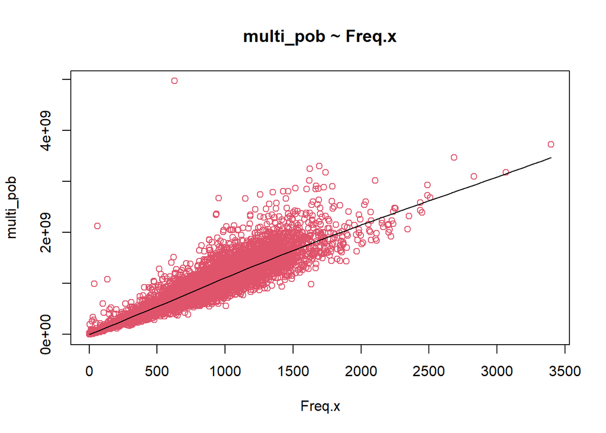

```r
scatter.smooth(x=h_y_m_comuna_corr_01$Freq.x, y=h_y_m_comuna_corr_01$multi_pob, main="multi_pob ~ Freq.x",
     xlab = "Freq.x",
     ylab = "multi_pob",
           col = 2)
```

### 7.2 Outliers

Hemos demostrado en el punto 5.7.2 de [aquí](https://rpubs.com/dataintelligence/expansion_viviendas_001) que la exclusión de ouliers no genera ninguna mejora en el modelo de regresión.

### 7.3 Modelo lineal

Aplicaremos un análisis de regresión lineal del ingreso expandido por zona sobre las frecuencias de respuestas zonales.

```r
linearMod <- lm( multi_pob~(Freq.x) , data=h_y_m_comuna_corr_01)
summary(linearMod)
```

```
##
## Call:
## lm(formula = multi_pob ~ (Freq.x), data = h_y_m_comuna_corr_01)
##
## Residuals:
##        Min         1Q     Median         3Q        Max
## -866166024 -128027627  -19964956   90311350 4257048837
##
## Coefficients:
##             Estimate Std. Error t value Pr(>|t|)
## (Intercept)  8085772    6978912   1.159    0.247
## Freq.x       1125930       7240 155.517   <2e-16 ***
## ---
## Signif. codes:  0 '***' 0.001 '**' 0.01 '*' 0.05 '.' 0.1 ' ' 1
##
## Residual standard error: 235400000 on 5138 degrees of freedom
## Multiple R-squared:  0.8248, Adjusted R-squared:  0.8247
## F-statistic: 2.419e+04 on 1 and 5138 DF,  p-value: < 2.2e-16
```

### 7.4 Gráfica de la recta de regresión lineal

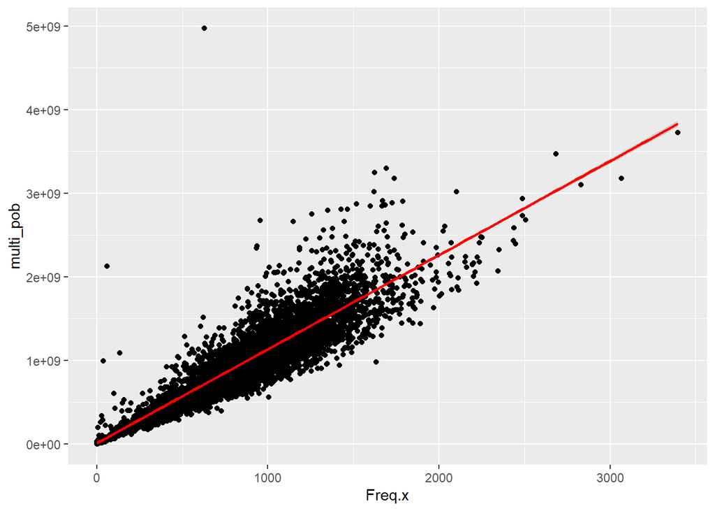

```r
ggplot(h_y_m_comuna_corr_01, aes(x = Freq.x , y = multi_pob)) +
  geom_point() +
  stat_smooth(method = "lm", col = "red")
```

## 8 Modelos alternativos

```r
### 8.1 Modelo cuadrático

linearMod <- lm( multi_pob~(Freq.x^2) , data=h_y_m_comuna_corr_01)
datos <- summary(linearMod)
dato <- datos$adj.r.squared
modelo <- "cuadrático"
sintaxis <- "linearMod <- lm( multi_pob~(Freq.x^2) , data=h_y_m_comuna_corr_01)"
latex <- "$$ '\'hat Y = '\'beta_0 + '\'beta_1  X^2  $$"
modelos1 <- cbind(modelo,dato,sintaxis,latex)

### 8.2 Modelo cúbico

linearMod <- lm( multi_pob~(Freq.x^3) , data=h_y_m_comuna_corr_01)
datos <- summary(linearMod)
dato <- datos$adj.r.squared
modelo <- "cúbico"
sintaxis <- "linearMod <- lm( multi_pob~(Freq.x^3) , data=h_y_m_comuna_corr_01)"
latex <- "$$ '\'hat Y = '\'beta_0 + '\'beta_1  X^3  $$"
modelos2 <- cbind(modelo,dato,sintaxis,latex)

### 8.3 Modelo logarítmico

linearMod <- lm( multi_pob~log(Freq.x) , data=h_y_m_comuna_corr_01)
datos <- summary(linearMod)
dato <- datos$adj.r.squared
modelo <- "logarítmico"
sintaxis <- "linearMod <- lm( multi_pob~log(Freq.x) , data=h_y_m_comuna_corr_01)"
latex <- "$$ '\'hat Y = '\'beta_0 + '\'beta_1 ln X  $$"
modelos3 <- cbind(modelo,dato,sintaxis,latex)

### 8.5 Modelo con raíz cuadrada

linearMod <- lm( multi_pob~sqrt(Freq.x) , data=h_y_m_comuna_corr_01)
datos <- summary(linearMod)
dato <- datos$adj.r.squared
modelo <- "raíz cuadrada"
sintaxis <- "linearMod <- lm( multi_pob~sqrt(Freq.x) , data=h_y_m_comuna_corr_01)"
latex <- "$$ '\'hat Y = '\'beta_0 + '\'beta_1  '\'sqrt {X}  $$"
modelos5 <- cbind(modelo,dato,sintaxis,latex)

### 8.6 Modelo raíz-raíz

linearMod <- lm( sqrt(multi_pob)~sqrt(Freq.x) , data=h_y_m_comuna_corr_01)
datos <- summary(linearMod)
dato <- datos$adj.r.squared
modelo <- "raíz-raíz"
sintaxis <- "linearMod <- lm( sqrt(multi_pob)~sqrt(Freq.x) , data=h_y_m_comuna_corr_01)"
latex <- "$$ '\'hat Y = {'\'beta_0}^2 + 2  '\'beta_0  '\'beta_1 '\'sqrt{X}+  '\'beta_1^2 X  $$"
modelos6 <- cbind(modelo,dato,sintaxis,latex)

### 8.7 Modelo log-raíz

linearMod <- lm( log(multi_pob)~sqrt(Freq.x) , data=h_y_m_comuna_corr_01)
datos <- summary(linearMod)
dato <- datos$adj.r.squared
modelo <- "log-raíz"
sintaxis <- "linearMod <- lm( log(multi_pob)~sqrt(Freq.x) , data=h_y_m_comuna_corr_01)"
latex <- "$$ '\'hat Y = e^{'\'beta_0 + '\'beta_1 '\'sqrt{X}} $$"
modelos7 <- cbind(modelo,dato,sintaxis,latex)

### 8.8 Modelo raíz-log

linearMod <- lm( sqrt(multi_pob)~log(Freq.x) , data=h_y_m_comuna_corr_01)
datos <- summary(linearMod)
dato <- datos$adj.r.squared
modelo <- "raíz-log"
sintaxis <- "linearMod <- lm( sqrt(multi_pob)~log(Freq.x) , data=h_y_m_comuna_corr_01)"
latex <- "$$ '\'hat Y = {'\'beta_0}^2 + 2  '\'beta_0  '\'beta_1 '\'ln{X}+  '\'beta_1^2 ln^2X  $$"
modelos8 <- cbind(modelo,dato,sintaxis,latex)

### 8.9 Modelo log-log

linearMod <- lm( log(multi_pob)~log(Freq.x) , data=h_y_m_comuna_corr_01)
datos <- summary(linearMod)
dato <- datos$adj.r.squared
modelo <- "log-log"
sintaxis <- "linearMod <- lm( log(multi_pob)~log(Freq.x) , data=h_y_m_comuna_corr_01)"
latex <- "$$ '\'hat Y = e^{'\'beta_0+'\'beta_1  ln{X}} $$"
modelos9 <- cbind(modelo,dato,sintaxis,latex)

modelos_bind <- rbind(modelos1,modelos2,modelos3,modelos5,modelos6,modelos7,modelos8,modelos9)
modelos_bind <- as.data.frame(modelos_bind)

modelos_bind <<- modelos_bind[order(modelos_bind$dato ),]
h_y_m_comuna_corr_01 <<- h_y_m_comuna_corr_01

kbl(modelos_bind) %>%
  kable_styling(bootstrap_options = c("striped", "hover")) %>%
  kable_paper() %>%
  scroll_box(width = "100%", height = "300px")
```

|  | modelo | dato | sintaxis | latex |
| --- | --- | --- | --- | --- |
| 3 | logarítmico | 0.538593064578472 | linearMod <- lm( multi_pob~log(Freq.x) , data=h_y_m_comuna_corr_01) | $$''hat Y = ''beta_0 + ''beta_1 ln X$$ |
| 7 | raíz-log | 0.761849706721933 | linearMod <- lm( sqrt(multi_pob)~log(Freq.x) , data=h_y_m_comuna_corr_01) | $$''hat Y = {''beta_0}^2 + 2 ''beta_0 ''beta_1 ''ln{X}+ ''beta_1^2 ln^2X$$ |
| 4 | raíz cuadrada | 0.774444506792838 | linearMod <- lm( multi_pob~sqrt(Freq.x) , data=h_y_m_comuna_corr_01) | $$''hat Y = ''beta_0 + ''beta_1 ''sqrt {X}$$ |
| 6 | log-raíz | 0.810163266160748 | linearMod <- lm( log(multi_pob)~sqrt(Freq.x) , data=h_y_m_comuna_corr_01) | $$''hat Y = e^{''beta_0 + ''beta_1 ''sqrt{X}}$$ |
| 1 | cuadrático | 0.824748646748287 | linearMod <- lm( multi_pob~(Freq.x^2) , data=h_y_m_comuna_corr_01) | $$''hat Y = ''beta_0 + ''beta_1 X^2$$ |
| 2 | cúbico | 0.824748646748287 | linearMod <- lm( multi_pob~(Freq.x^3) , data=h_y_m_comuna_corr_01) | $$''hat Y = ''beta_0 + ''beta_1 X^3$$ |
| 5 | raíz-raíz | 0.89780713641786 | linearMod <- lm( sqrt(multi_pob)~sqrt(Freq.x) , data=h_y_m_comuna_corr_01) | $$''hat Y = {''beta_0}^2 + 2 ''beta_0 ''beta_1 ''sqrt{X}+ ''beta_1^2 X$$ |
| 8 | log-log | 0.951121143823652 | linearMod <- lm( log(multi_pob)~log(Freq.x) , data=h_y_m_comuna_corr_01) | $$''hat Y = e^{''beta_0+''beta_1 ln{X}}$$ |

```r
h_y_m_comuna_corr <- h_y_m_comuna_corr_01
metodo <- 8


switch (metodo,
        case = linearMod <- lm( multi_pob~(Freq.x^2) , data=h_y_m_comuna_corr),
        case = linearMod <- lm( multi_pob~(Freq.x^3) , data=h_y_m_comuna_corr),
        case = linearMod <- lm( multi_pob~log(Freq.x) , data=h_y_m_comuna_corr),
        case = linearMod <- lm( multi_pob~sqrt(Freq.x) , data=h_y_m_comuna_corr),
        case = linearMod <- lm( sqrt(multi_pob)~sqrt(Freq.x) , data=h_y_m_comuna_corr),
        case = linearMod <- lm( log(multi_pob)~sqrt(Freq.x) , data=h_y_m_comuna_corr),
        case = linearMod <- lm( sqrt(multi_pob)~log(Freq.x) , data=h_y_m_comuna_corr),
        case = linearMod <- lm( log(multi_pob)~log(Freq.x) , data=h_y_m_comuna_corr)
)
summary(linearMod)
```

```
##
## Call:
## lm(formula = log(multi_pob) ~ log(Freq.x), data = h_y_m_comuna_corr)
##
## Residuals:
##     Min      1Q  Median      3Q     Max
## -1.4766 -0.1546 -0.0129  0.1340  3.5227
##
## Coefficients:
##             Estimate Std. Error t value Pr(>|t|)
## (Intercept) 13.77079    0.02106   653.9   <2e-16 ***
## log(Freq.x)  1.02157    0.00323   316.2   <2e-16 ***
## ---
## Signif. codes:  0 '***' 0.001 '**' 0.01 '*' 0.05 '.' 0.1 ' ' 1
##
## Residual standard error: 0.2713 on 5138 degrees of freedom
## Multiple R-squared:  0.9511, Adjusted R-squared:  0.9511
## F-statistic: 1e+05 on 1 and 5138 DF,  p-value: < 2.2e-16
```

```r
aa <- linearMod$coefficients[1]
aa
```

```
## (Intercept)
##    13.77079
```

```r
bb <- linearMod$coefficients[2]
bb
```

```
## log(Freq.x)
##    1.021568
```

## 9 Modelo log-log (**log-log**)

### 9.1 Diagrama de dispersión sobre **log-log**

Desplegamos una curva suavizada por loess en el diagrama de dispersión.

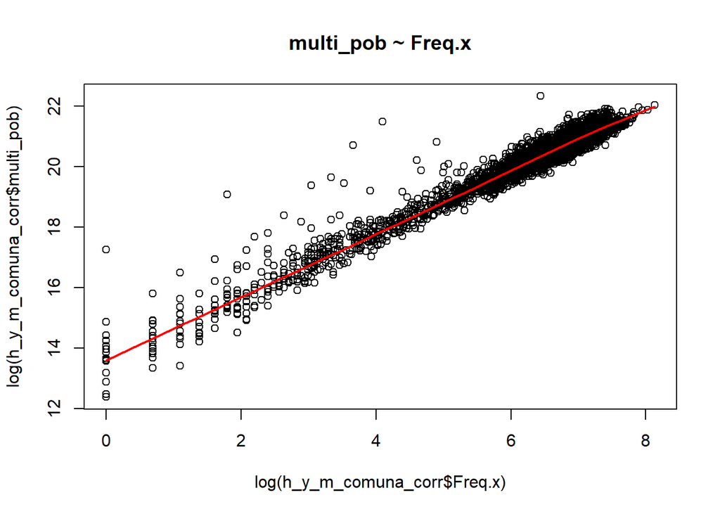

```r
scatter.smooth(x=log(h_y_m_comuna_corr$Freq.x), y=log(h_y_m_comuna_corr$multi_pob), lpars = list(col = "red", lwd = 2, lty = 1), main="multi_pob ~ Freq.x")
```

### 9.2 Modelo **log-log**

Observemos nuevamente el resultado sobre **log-log**.

```r
linearMod <- lm(log( multi_pob)~log(Freq.x) , data=h_y_m_comuna_corr)
summary(linearMod)
```

```
##
## Call:
## lm(formula = log(multi_pob) ~ log(Freq.x), data = h_y_m_comuna_corr)
##
## Residuals:
##     Min      1Q  Median      3Q     Max
## -1.4766 -0.1546 -0.0129  0.1340  3.5227
##
## Coefficients:
##             Estimate Std. Error t value Pr(>|t|)
## (Intercept) 13.77079    0.02106   653.9   <2e-16 ***
## log(Freq.x)  1.02157    0.00323   316.2   <2e-16 ***
## ---
## Signif. codes:  0 '***' 0.001 '**' 0.01 '*' 0.05 '.' 0.1 ' ' 1
##
## Residual standard error: 0.2713 on 5138 degrees of freedom
## Multiple R-squared:  0.9511, Adjusted R-squared:  0.9511
## F-statistic: 1e+05 on 1 and 5138 DF,  p-value: < 2.2e-16
```

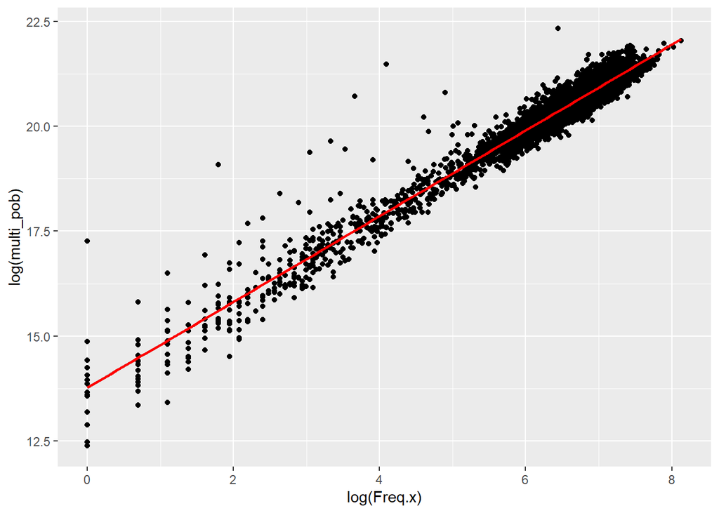

```r
ggplot(h_y_m_comuna_corr, aes(x = log(Freq.x) , y = log(multi_pob))) + geom_point() + stat_smooth(method = "lm", col = "red")
```

### 9.3 Análisis de residuos

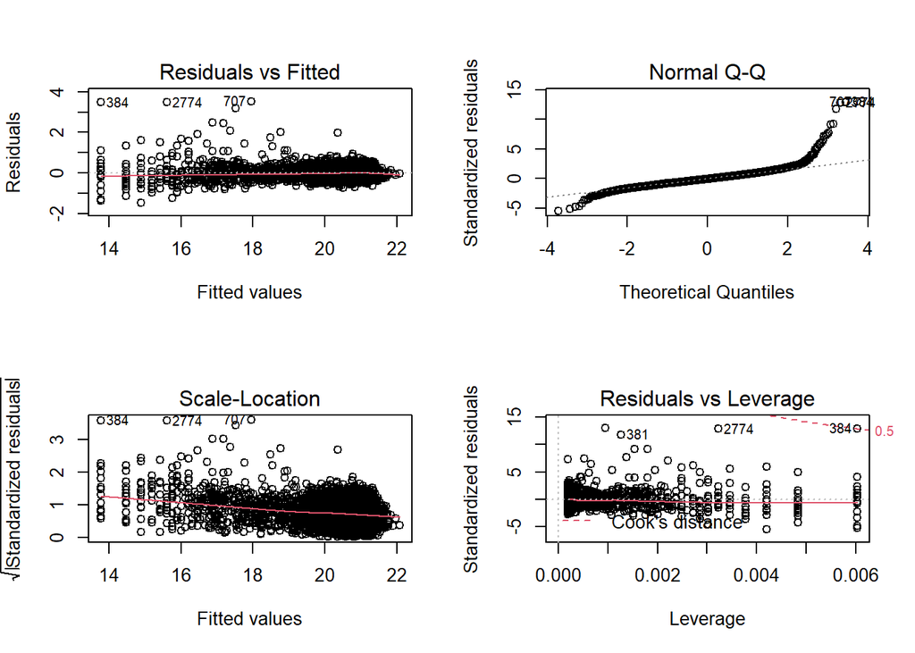

```r
par(mfrow = c (2,2))
plot(linearMod)
```

## 10 Aplicación la regresión a los valores de la variable a nivel de zona

Esta nueva variable se llamará: est_ing

```r
h_y_m_comuna_corr$est_ing <- exp(aa+bb * log(h_y_m_comuna_corr$Freq.x))

r3_100 <- h_y_m_comuna_corr[c(1:100),]
kbl(r3_100) %>%
  kable_styling(bootstrap_options = c("striped", "hover")) %>%
  kable_paper() %>%
  scroll_box(width = "100%", height = "300px")
```

| zona | código.x | Freq.x | anio | comuna.x | promedio_i | año | personas | Ingresos_expandidos | Freq.y | p_poblacional | código.y | multi_pob | est_ing |
| --- | --- | --- | --- | --- | --- | --- | --- | --- | --- | --- | --- | --- | --- |
| 10101011001 | 10101 | 181 | 2017 | Puerto Montt | 304409.6 | 2017 | 245902 | 74854925754 | 584 | 0.0023749 | 10101 | 177775197.6 | 193619221 |
| 10101011002 | 10101 | 964 | 2017 | Puerto Montt | 304409.6 | 2017 | 245902 | 74854925754 | 2941 | 0.0119600 | 10101 | 895268589.3 | 1069088950 |
| 10101021001 | 10101 | 1249 | 2017 | Puerto Montt | 304409.6 | 2017 | 245902 | 74854925754 | 3953 | 0.0160755 | 10101 | 1203331089.2 | 1392917271 |
| 10101021002 | 10101 | 328 | 2017 | Puerto Montt | 304409.6 | 2017 | 245902 | 74854925754 | 1107 | 0.0045018 | 10101 | 336981410.5 | 355395950 |
| 10101021003 | 10101 | 699 | 2017 | Puerto Montt | 304409.6 | 2017 | 245902 | 74854925754 | 2294 | 0.0093289 | 10101 | 698315587.8 | 769844661 |
| 10101021004 | 10101 | 1043 | 2017 | Puerto Montt | 304409.6 | 2017 | 245902 | 74854925754 | 3391 | 0.0137900 | 10101 | 1032252902.5 | 1158667687 |
| 10101021005 | 10101 | 773 | 2017 | Puerto Montt | 304409.6 | 2017 | 245902 | 74854925754 | 2564 | 0.0104269 | 10101 | 780506175.8 | 853194386 |
| 10101031001 | 10101 | 1468 | 2017 | Puerto Montt | 304409.6 | 2017 | 245902 | 74854925754 | 4530 | 0.0184220 | 10101 | 1378975419.7 | 1642866314 |
| 10101031002 | 10101 | 1424 | 2017 | Puerto Montt | 304409.6 | 2017 | 245902 | 74854925754 | 4740 | 0.0192760 | 10101 | 1442901432.6 | 1592579478 |
| 10101031003 | 10101 | 1163 | 2017 | Puerto Montt | 304409.6 | 2017 | 245902 | 74854925754 | 4107 | 0.0167018 | 10101 | 1250210165.3 | 1295013710 |
| 10101031004 | 10101 | 836 | 2017 | Puerto Montt | 304409.6 | 2017 | 245902 | 74854925754 | 2856 | 0.0116144 | 10101 | 869393774.6 | 924290863 |
| 10101031005 | 10101 | 1701 | 2017 | Puerto Montt | 304409.6 | 2017 | 245902 | 74854925754 | 5690 | 0.0231393 | 10101 | 1732090538.3 | 1909678953 |
| 10101031006 | 10101 | 704 | 2017 | Puerto Montt | 304409.6 | 2017 | 245902 | 74854925754 | 2460 | 0.0100040 | 10101 | 748847578.9 | 775470620 |
| 10101031007 | 10101 | 652 | 2017 | Puerto Montt | 304409.6 | 2017 | 245902 | 74854925754 | 2292 | 0.0093208 | 10101 | 697706768.7 | 717003924 |
| 10101031008 | 10101 | 1013 | 2017 | Puerto Montt | 304409.6 | 2017 | 245902 | 74854925754 | 3585 | 0.0145790 | 10101 | 1091308362.0 | 1124632583 |
| 10101031009 | 10101 | 1347 | 2017 | Puerto Montt | 304409.6 | 2017 | 245902 | 74854925754 | 4436 | 0.0180397 | 10101 | 1350360918.8 | 1504658767 |
| 10101031010 | 10101 | 910 | 2017 | Puerto Montt | 304409.6 | 2017 | 245902 | 74854925754 | 3566 | 0.0145017 | 10101 | 1085524579.9 | 1007948243 |
| 10101031011 | 10101 | 666 | 2017 | Puerto Montt | 304409.6 | 2017 | 245902 | 74854925754 | 2757 | 0.0112118 | 10101 | 839257225.7 | 732735386 |
| 10101031012 | 10101 | 499 | 2017 | Puerto Montt | 304409.6 | 2017 | 245902 | 74854925754 | 1849 | 0.0075193 | 10101 | 562853322.5 | 545593805 |
| 10101031013 | 10101 | 1055 | 2017 | Puerto Montt | 304409.6 | 2017 | 245902 | 74854925754 | 3945 | 0.0160430 | 10101 | 1200895812.6 | 1172287677 |
| 10101031014 | 10101 | 645 | 2017 | Puerto Montt | 304409.6 | 2017 | 245902 | 74854925754 | 2265 | 0.0092110 | 10101 | 689487709.9 | 709140915 |
| 10101031015 | 10101 | 541 | 2017 | Puerto Montt | 304409.6 | 2017 | 245902 | 74854925754 | 1930 | 0.0078487 | 10101 | 587510498.9 | 592547423 |
| 10101031016 | 10101 | 773 | 2017 | Puerto Montt | 304409.6 | 2017 | 245902 | 74854925754 | 3071 | 0.0124887 | 10101 | 934841835.3 | 853194386 |
| 10101031017 | 10101 | 821 | 2017 | Puerto Montt | 304409.6 | 2017 | 245902 | 74854925754 | 3885 | 0.0157990 | 10101 | 1182631237.5 | 907352308 |
| 10101041001 | 10101 | 1331 | 2017 | Puerto Montt | 304409.6 | 2017 | 245902 | 74854925754 | 4342 | 0.0176574 | 10101 | 1321746417.8 | 1486402928 |
| 10101041002 | 10101 | 644 | 2017 | Puerto Montt | 304409.6 | 2017 | 245902 | 74854925754 | 2169 | 0.0088206 | 10101 | 660264389.7 | 708017778 |
| 10101041003 | 10101 | 1650 | 2017 | Puerto Montt | 304409.6 | 2017 | 245902 | 74854925754 | 5202 | 0.0211548 | 10101 | 1583538660.8 | 1851206456 |
| 10101051001 | 10101 | 825 | 2017 | Puerto Montt | 304409.6 | 2017 | 245902 | 74854925754 | 2463 | 0.0100162 | 10101 | 749760807.7 | 911868609 |
| 10101051002 | 10101 | 579 | 2017 | Puerto Montt | 304409.6 | 2017 | 245902 | 74854925754 | 1913 | 0.0077795 | 10101 | 582335536.0 | 635097295 |
| 10101051003 | 10101 | 888 | 2017 | Puerto Montt | 304409.6 | 2017 | 245902 | 74854925754 | 3272 | 0.0133061 | 10101 | 996028161.9 | 983061238 |

[output cut: 70 more lines]

## 11 División del valor estimado entre la población total de la zona para obtener el ingreso medio por zona

$$Ingreso \_ Medio\_zona = est\_ing / (personas * p\_poblacional)$$

```r
h_y_m_comuna_corr$ing_medio_zona <- h_y_m_comuna_corr$est_ing  /( h_y_m_comuna_corr$personas  * h_y_m_comuna_corr$p_poblacional)

r3_100 <- h_y_m_comuna_corr[c(1:100),]
kbl(r3_100) %>%
  kable_styling(bootstrap_options = c("striped", "hover")) %>%
  kable_paper() %>%
  scroll_box(width = "100%", height = "300px")
```

| zona | código.x | Freq.x | anio | comuna.x | promedio_i | año | personas | Ingresos_expandidos | Freq.y | p_poblacional | código.y | multi_pob | est_ing | ing_medio_zona |
| --- | --- | --- | --- | --- | --- | --- | --- | --- | --- | --- | --- | --- | --- | --- |
| 10101011001 | 10101 | 181 | 2017 | Puerto Montt | 304409.6 | 2017 | 245902 | 74854925754 | 584 | 0.0023749 | 10101 | 177775197.6 | 193619221 | 331539.76 |
| 10101011002 | 10101 | 964 | 2017 | Puerto Montt | 304409.6 | 2017 | 245902 | 74854925754 | 2941 | 0.0119600 | 10101 | 895268589.3 | 1069088950 | 363512.05 |
| 10101021001 | 10101 | 1249 | 2017 | Puerto Montt | 304409.6 | 2017 | 245902 | 74854925754 | 3953 | 0.0160755 | 10101 | 1203331089.2 | 1392917271 | 352369.66 |
| 10101021002 | 10101 | 328 | 2017 | Puerto Montt | 304409.6 | 2017 | 245902 | 74854925754 | 1107 | 0.0045018 | 10101 | 336981410.5 | 355395950 | 321044.22 |
| 10101021003 | 10101 | 699 | 2017 | Puerto Montt | 304409.6 | 2017 | 245902 | 74854925754 | 2294 | 0.0093289 | 10101 | 698315587.8 | 769844661 | 335590.52 |
| 10101021004 | 10101 | 1043 | 2017 | Puerto Montt | 304409.6 | 2017 | 245902 | 74854925754 | 3391 | 0.0137900 | 10101 | 1032252902.5 | 1158667687 | 341689.09 |
| 10101021005 | 10101 | 773 | 2017 | Puerto Montt | 304409.6 | 2017 | 245902 | 74854925754 | 2564 | 0.0104269 | 10101 | 780506175.8 | 853194386 | 332759.12 |
| 10101031001 | 10101 | 1468 | 2017 | Puerto Montt | 304409.6 | 2017 | 245902 | 74854925754 | 4530 | 0.0184220 | 10101 | 1378975419.7 | 1642866314 | 362663.65 |
| 10101031002 | 10101 | 1424 | 2017 | Puerto Montt | 304409.6 | 2017 | 245902 | 74854925754 | 4740 | 0.0192760 | 10101 | 1442901432.6 | 1592579478 | 335987.23 |
| 10101031003 | 10101 | 1163 | 2017 | Puerto Montt | 304409.6 | 2017 | 245902 | 74854925754 | 4107 | 0.0167018 | 10101 | 1250210165.3 | 1295013710 | 315318.65 |
| 10101031004 | 10101 | 836 | 2017 | Puerto Montt | 304409.6 | 2017 | 245902 | 74854925754 | 2856 | 0.0116144 | 10101 | 869393774.6 | 924290863 | 323631.25 |
| 10101031005 | 10101 | 1701 | 2017 | Puerto Montt | 304409.6 | 2017 | 245902 | 74854925754 | 5690 | 0.0231393 | 10101 | 1732090538.3 | 1909678953 | 335620.20 |
| 10101031006 | 10101 | 704 | 2017 | Puerto Montt | 304409.6 | 2017 | 245902 | 74854925754 | 2460 | 0.0100040 | 10101 | 748847578.9 | 775470620 | 315231.96 |
| 10101031007 | 10101 | 652 | 2017 | Puerto Montt | 304409.6 | 2017 | 245902 | 74854925754 | 2292 | 0.0093208 | 10101 | 697706768.7 | 717003924 | 312828.94 |
| 10101031008 | 10101 | 1013 | 2017 | Puerto Montt | 304409.6 | 2017 | 245902 | 74854925754 | 3585 | 0.0145790 | 10101 | 1091308362.0 | 1124632583 | 313705.04 |
| 10101031009 | 10101 | 1347 | 2017 | Puerto Montt | 304409.6 | 2017 | 245902 | 74854925754 | 4436 | 0.0180397 | 10101 | 1350360918.8 | 1504658767 | 339192.69 |
| 10101031010 | 10101 | 910 | 2017 | Puerto Montt | 304409.6 | 2017 | 245902 | 74854925754 | 3566 | 0.0145017 | 10101 | 1085524579.9 | 1007948243 | 282655.14 |
| 10101031011 | 10101 | 666 | 2017 | Puerto Montt | 304409.6 | 2017 | 245902 | 74854925754 | 2757 | 0.0112118 | 10101 | 839257225.7 | 732735386 | 265772.72 |
| 10101031012 | 10101 | 499 | 2017 | Puerto Montt | 304409.6 | 2017 | 245902 | 74854925754 | 1849 | 0.0075193 | 10101 | 562853322.5 | 545593805 | 295075.07 |
| 10101031013 | 10101 | 1055 | 2017 | Puerto Montt | 304409.6 | 2017 | 245902 | 74854925754 | 3945 | 0.0160430 | 10101 | 1200895812.6 | 1172287677 | 297157.84 |
| 10101031014 | 10101 | 645 | 2017 | Puerto Montt | 304409.6 | 2017 | 245902 | 74854925754 | 2265 | 0.0092110 | 10101 | 689487709.9 | 709140915 | 313086.50 |
| 10101031015 | 10101 | 541 | 2017 | Puerto Montt | 304409.6 | 2017 | 245902 | 74854925754 | 1930 | 0.0078487 | 10101 | 587510498.9 | 592547423 | 307019.39 |
| 10101031016 | 10101 | 773 | 2017 | Puerto Montt | 304409.6 | 2017 | 245902 | 74854925754 | 3071 | 0.0124887 | 10101 | 934841835.3 | 853194386 | 277822.98 |
| 10101031017 | 10101 | 821 | 2017 | Puerto Montt | 304409.6 | 2017 | 245902 | 74854925754 | 3885 | 0.0157990 | 10101 | 1182631237.5 | 907352308 | 233552.72 |
| 10101041001 | 10101 | 1331 | 2017 | Puerto Montt | 304409.6 | 2017 | 245902 | 74854925754 | 4342 | 0.0176574 | 10101 | 1321746417.8 | 1486402928 | 342331.40 |
| 10101041002 | 10101 | 644 | 2017 | Puerto Montt | 304409.6 | 2017 | 245902 | 74854925754 | 2169 | 0.0088206 | 10101 | 660264389.7 | 708017778 | 326425.90 |
| 10101041003 | 10101 | 1650 | 2017 | Puerto Montt | 304409.6 | 2017 | 245902 | 74854925754 | 5202 | 0.0211548 | 10101 | 1583538660.8 | 1851206456 | 355864.37 |
| 10101051001 | 10101 | 825 | 2017 | Puerto Montt | 304409.6 | 2017 | 245902 | 74854925754 | 2463 | 0.0100162 | 10101 | 749760807.7 | 911868609 | 370226.80 |
| 10101051002 | 10101 | 579 | 2017 | Puerto Montt | 304409.6 | 2017 | 245902 | 74854925754 | 1913 | 0.0077795 | 10101 | 582335536.0 | 635097295 | 331990.22 |
| 10101051003 | 10101 | 888 | 2017 | Puerto Montt | 304409.6 | 2017 | 245902 | 74854925754 | 3272 | 0.0133061 | 10101 | 996028161.9 | 983061238 | 300446.59 |

[output cut: 70 more lines]

Guardamos:

```r
saveRDS(h_y_m_comuna_corr, "P03C/region_01_P03C_u.rds")
```

## 12 Referencias

https://rpubs.com/osoramirez/316691

https://dataintelligencechile.shinyapps.io/casenfinal

Manual_de_usuario_Censo_2017_16R.pdf

http://www.censo2017.cl/microdatos/

Censo de Población y Vivienda

https://www.ine.cl/estadisticas/sociales/censos-de-poblacion-y-vivienda/poblacion-y-vivienda

http://r-statistics.co/Linear-Regression.html